# Bunkers

Adela Sobotkova

2022-11-12

## Visualize military installations on the Cold-War border

Yambol region borders on Turkey and Greece and with the Tundzha River flowing through the border in a deep ravine overgrown with forests, this region represented a prime ground for birectional movement. Movement of populations is posited here since the first farming immigrants in the 6th millennium. As the arid conditions of the early Holocene were letting up and humidity allowed for higher vegetation to spread, the first farmers settled near the Tundzha River, planting crops and building the first permanent settlements in the area. 8000 years later, this was an administrative border between two hostile worlds, carefully guarded and with restricted movement. Military forces on both sides set up observation posts and defensive locations so as to keep control over the territory.

This scripts visualizes the locations of military installations recorded in place of burial mounds (symbols in Soviet topographic maps).

To DOES: - national boundaries - all map mounds needed!

```r
library(tidyverse)
library(sf)
library(raster)
```

## Load 2009-2022 mound data and 2018 - 2022 military feature data

```r
getwd()
```

```
[1] "C:/Users/au616760/Documents/RStudio/YambolMoundAnalysis/scripts"
```

```r
Yam_mnds <- readRDS("../output_data/features_dd_later_27Dec.rds")
Yam_mil <- read_csv("../output_data/MIlitaryFeatures-OR12Dec22.csv")
mapmnds <- read_sf("../data/MapMounds32635.shp")
```

### Explore the data a bit

```r
tail(Yam_mil)
```

```
# A tibble: 6 x 10
  Column MoundID Type                DescriptionOfMo~ PositionInTheLa~ Condition
   <dbl>   <dbl> <chr>               <chr>            <chr>            <chr>
1    206    8796 Burial Mound        large mound at ~ Hilltop          3 - dama~
2    211    8652 Uncertain Feature   uncertain featu~ Valley Bottom o~ 0 - No o~
3    212    8798 Extinct Burial Mou~ Mound on field ~ <NA>             5 - exti~
4   2371    8658 Burial Mound        South from Nedy~ Upper slope      4 - seri~
5    254    8666 Other               bunker, overgro~ Lower slope      3 - dama~
6     NA      NA <NA>                <NA>             <NA>             <NA>
# ... with 4 more variables: Feature_Facing <chr>, FacingDirection <chr>,
#   Image_Verification <chr>, CentralFeature <chr>
```

```r
Yam_mil <- Yam_mil[-79, ]

unique(Yam_mil$FacingDirection)
```

```
[1] NA          "Northeast" "North"     "South"     "East"      "West"
[7] "Southeast" "Southwest"
```

```r
unique(Yam_mil$CentralFeature)
```

```
[1] "Bunker"              "Vehicle emplacement" "Tank emplacement"
[4] NA                    "Infantry trench"
```

```r
# Yam_mil$feature.facing <- factor(Yam_mil$feature.facing)

Yam_mil %>%
    group_by(CentralFeature) %>%
    count() %>%
    arrange(desc(n))
```

```
# A tibble: 5 x 2
# Groups:   CentralFeature [5]
  CentralFeature          n
  <chr>               <int>
1 Vehicle emplacement    25
2 Bunker                 24
3 Infantry trench        12
4 Tank emplacement       12
5 <NA>                    5
```

## Load elevation raster and Yambol region boundary

```r
Y_region <- st_read("../data/YamRegion.shp")
```

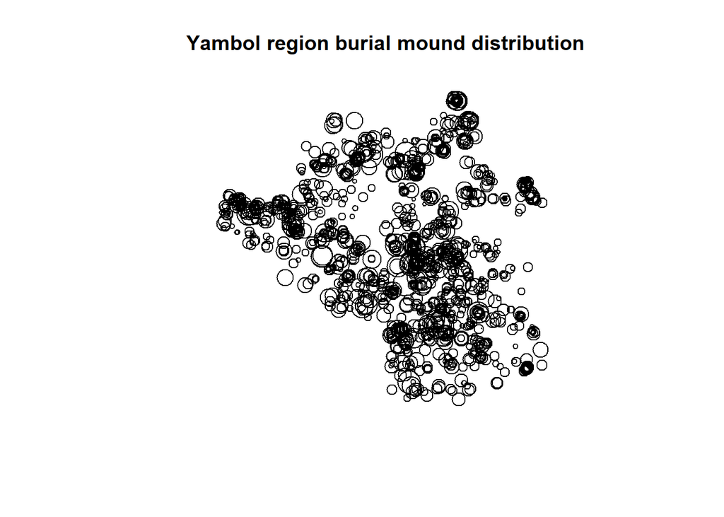

```r
Y_elev <- raster("../output_data/large/Yelev32635.tif")
plot(Yam_mnds$geometry, cex = sqrt(as.numeric(Yam_mnds$HeightMax)), main = " Yambol region burial mound distribution")
```

## Map mounds are good for the background, but now the file contains all kinds of benchmarks. Let’s filter to the sunburst, brown sunburst-like symbol, which in 99% cases leads to a burial mound.

```r
table(mapmnds$MpSymbl)  # 'circle' seems the best think to search on with ca 4289records
```

```
                    Black diamond with a dot inside
                                               3225
                     Black square with a dot inside
                                               1334
                   Black triangle with a dot inside
                                                923
              Hairy black diamond with a dot inside
                                                620
               Hairy black square with a dot inside
                                                 93
             Hairy black triangle with a dot inside
                                                300
                                 Hairy brown circle
                                               4289
      Hairy brown circle (has black diamond on top)
                                                  1
                     Other (describe in annotation)
                                                 19
    Other (describe in annotation) (brown circle??)
                                                  1
     Other (describe in annotation) (brown started)
                                                  1
Other (describe in annotation) (hairy black circle)
                                                  3
```

```r
mapmnds <- mapmnds %>%
    filter(grepl("circle", MpSymbl))
mapmnds
```

```
Simple feature collection with 4294 features and 24 fields
Geometry type: POINT
Dimension:     XY
Bounding box:  xmin: 292657 ymin: 4613657 xmax: 557513.3 ymax: 4742328
Projected CRS: WGS 84 / UTM zone 35N
# A tibble: 4,294 x 25
      uuid identfr cretdBy     crtAGMT modfdBy mdfAGMT     ID FtrAthr FtrTmst
 *   <dbl>   <dbl> <chr>       <chr>   <chr>   <chr>    <dbl> <chr>   <date>
 1 1.00e18  202200 Stephanie ~ 2017-0~ Stepha~ 2017-0~ 202200 Stepha~ 2017-09-17
 2 1.00e18  202000 Stephanie ~ 2017-0~ Stepha~ 2017-0~ 202000 Stepha~ 2017-09-18
 3 1.00e18  202005 Stephanie ~ 2017-0~ Stepha~ 2017-0~ 202005 Stepha~ 2017-09-18
 4 1.00e18  202006 Stephanie ~ 2017-0~ Stepha~ 2017-0~ 202006 Stepha~ 2017-09-18
 5 1.00e18  202009 Stephanie ~ 2017-0~ Stepha~ 2017-0~ 202009 Stepha~ 2017-09-18
 6 1.00e18  202010 Stephanie ~ 2017-0~ Stepha~ 2017-0~ 202010 Stepha~ 2017-09-18
 7 1.00e18  202016 Stephanie ~ 2017-0~ Stepha~ 2017-0~ 202016 Stepha~ 2017-09-18
 8 1.00e18  202017 Stephanie ~ 2017-0~ Stepha~ 2017-0~ 202017 Stepha~ 2017-09-18
 9 1.00e18  202226 Lachlan Ha~ 2017-0~ Lachla~ 2017-0~ 202226 Lachla~ 2017-09-18
10 1.00e18  202227 Lachlan Ha~ 2017-0~ Lachla~ 2017-0~ 202227 Lachla~ 2017-09-18
# ... with 4,284 more rows, and 16 more variables: Latitud <dbl>,
#   Longitd <dbl>, Accurcy <int>, FetrTyp <chr>, MpSymbl <chr>, Source <chr>,
#   Note <chr>, GC <chr>, DtCmplt <chr>, Dscrptn <int>, Clssfct <int>,
#   OthrDsc <int>, Picture <int>, gsptlcl <chr>, year <chr>,
#   geometry <POINT [m]>
```

```r
Y_region
```

```
Simple feature collection with 1 feature and 7 fields
Geometry type: POLYGON
Dimension:     XY
Bounding box:  xmin: 431400.8 ymin: 4641684 xmax: 504849.3 ymax: 4727299
Projected CRS: WGS 84 / UTM zone 35N
  OBJECTID                                  Name_bg Name_en EKATTE District_c
1       15 Ямбол  Yambol  87374        JAM
  SHAPE_Leng SHAPE_Area                       geometry
1     423356 3352820244 POLYGON ((473018.1 4727294,...
```

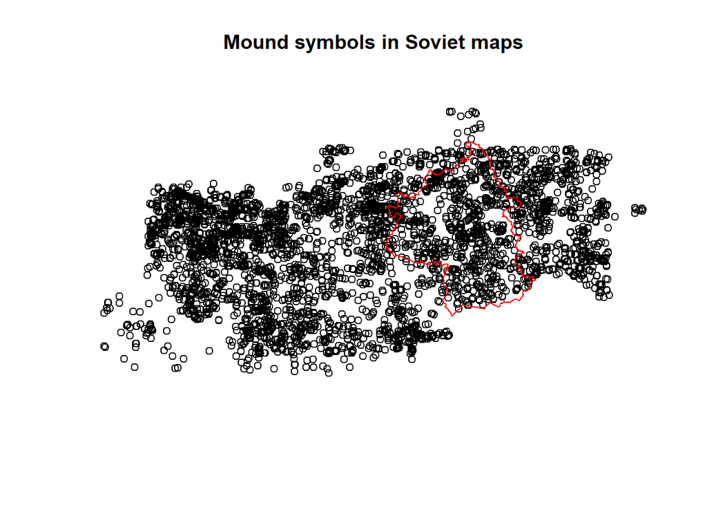

```r
plot(mapmnds$geometry, main = "Mound symbols in Soviet maps")
plot(Y_region$geometry, border = "red", add = T)
```

## Plot with mapview

Mapview is great for interactive vieweing in the digital document.

```r
Yam_bunkers <- Yam_mnds %>%
    dplyr::filter(TRAP %in% Yam_mil$MoundID) %>%
    full_join(Yam_mil, by = c(TRAP = "MoundID"))


library(mapview)
Yam_bunkers$CentralFeature <- factor(Yam_bunkers$CentralFeature)
levels(Yam_bunkers$CentralFeature) <- c("Bunker", "Infantry trench", "Tank emplacement",
    "Vehicle emplacement")

mapview(Yam_mnds, cex = 1) + mapview(Yam_bunkers, zcol = "CentralFeature")
```

[interactive chart not shown]

## Great, let’s explore different plotting packages

circle = bunkers, 19, 20, 21 - color fill square = trench, 7, 22 u/horseshoe = emplacement, 18, 25 mund triangle - 2,17,24

Maps: 1: Yambol with all mounds with an inset of BG (no topography, minimalist graphics) 2: Border region with mounds and military installations visually differentiated 3: Typology of mil.installations 4: Sitovo site with different installations?

### Yambol with an inset of BG - Leaflet

```r
library(leaflet)
library(leafem)
leaflet() %>%
    addProviderTiles("Esri.WorldImagery") %>%
    addCircleMarkers(data = st_transform(Yam_bunkers, 4326)) %>%
    addMiniMap(toggleDisplay = TRUE, position = "bottomright")
```

[interactive chart not shown]

## Mounds in tmaps

Let’s create a printable overview Tmap differentiating between Yambol mounds/features and military installations

## Overview

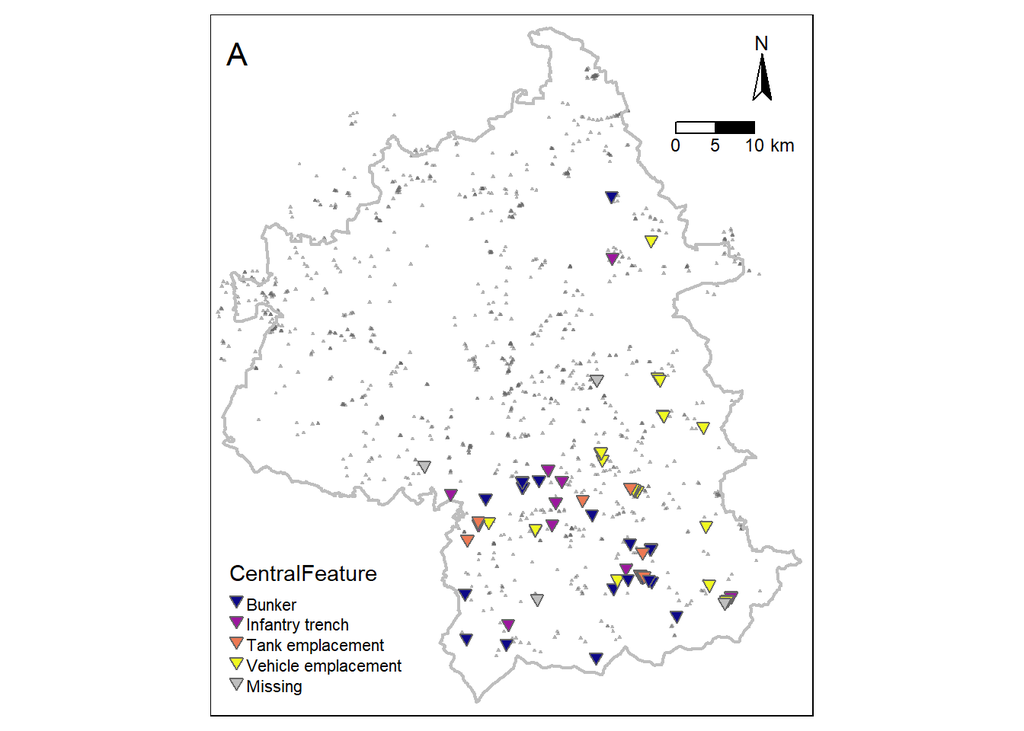

```r
library(tmap)
# all the features throughout the region
overview_mapmnds <- tm_shape(mapmnds, bbox = st_bbox(Y_region))+
  tm_symbols(shape = 2,
             col="#666666",
             alpha = 0.5,
             size = 0.01) +
# regional boundary
tm_shape(Y_region) +
 tm_borders(col = "grey",
              lwd = 2)+
# military installations
tm_shape(Yam_bunkers, bbox = st_bbox(Y_region)) +
  # tm_polygons(col="cornsilk2", border.alpha = 0)+
  # tm_shape(features) +
  tm_symbols(shape = 25,
             col="CentralFeature",
             palette = "plasma", # try Set2 ,Set3, viridis or other palettes
          #   title = "Feature type",
             size = 0.2) +  #6 and 25 are downward triangles
  tm_compass(type = "arrow",
             position = c("right", "top")) +
  tm_scale_bar(position = c("right", "top"),
               breaks = c(0,5,10),
               text.size = 0.75) +
  #tm_credits("Sobotkova 2020", position = c("right", "bottom"), size = 0.8) +
  #tm_layout(title = "Registered standing features")
  tm_layout(title = "A",
            legend.position = c("left", "bottom"))

overview_yammnds <- tm_shape(Yam_mnds, bbox = st_bbox(Y_region))+
  tm_symbols(shape = 2,
             col="#666666",
             alpha = 0.5,
             size = 0.01) +
# regional boundary
tm_shape(Y_region) +
 tm_borders(col = "grey",
              lwd = 2)+
# military installations
tm_shape(Yam_bunkers, bbox = st_bbox(Y_region)) +
  # tm_polygons(col="cornsilk2", border.alpha = 0)+
  # tm_shape(features) +
  tm_symbols(shape = 25,
             col="CentralFeature",
             palette = "plasma", # try Set2 ,Set3, viridis or other palettes
          #   title = "Feature type",
             size = 0.2) +  #6 and 25 are downward triangles
  tm_compass(type = "arrow",
             position = c("right", "top")) +
  tm_scale_bar(position = c("right", "top"),
               breaks = c(0,5,10),
               text.size = 0.75) +
  #tm_credits("Sobotkova 2020", position = c("right", "bottom"), size = 0.8) +
  #tm_layout(title = "Registered standing features")
  tm_layout(title = "A",
            legend.position = c("left", "bottom"))

overview_yammnds
```

## Military feature typology - detailed views

We need maps zooming in to differentiate the different locations of vehicle emplacements versus bunkers/observation towers etc.

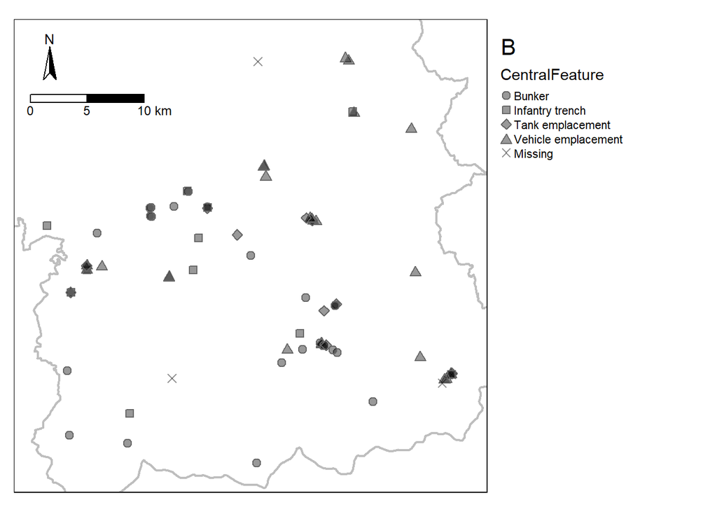

```r
library(tmap)
tm_shape(Yam_bunkers, bbox = st_bbox(st_buffer(st_geometry(Yam_bunkers[1,]), 20000))) +
  tm_dots( shape = "CentralFeature", #6 and 26 are downward triangles
            alpha= 0.4,
            title = "Type of \nmilitary features",
             size = 0.3) +
tm_shape(Y_region) +
 tm_borders(col = "grey",
              lwd = 2)+
  tm_compass(type = "arrow",
             position = c("left", "top")) +
  tm_scale_bar(position = c("left", "top"),
               breaks = c(0,5,10),
               text.size = 0.75)  +
  tm_layout(title = "B", legend.outside = TRUE)
```

## Facing directions

The direction the vehicle emplacements and other features are pointing can tell us about their role: offensive or defensive?

```r
table(Yam_bunkers$FacingDirection)
```

```
     East     North Northeast     South Southeast Southwest      West
        7         2         2        22         3         3         5
```

```r
Yam_bunkers <- Yam_bunkers %>%
    # st_drop_geometry() %>%
mutate(FD = case_when(FacingDirection == "Southeast" ~ "South", FacingDirection ==
    "Southwest" ~ "South", FacingDirection == "Northeast" ~ "North", FacingDirection ==
    "South" ~ "South", FacingDirection == "North" ~ "North", FacingDirection == "East" ~
    "East", FacingDirection == "West" ~ "West"))

table(Yam_bunkers$Feature_Facing)
```

```
 Cannot tell    Collapsed         East   No drawing        North    Northeast
           3            1            7            1            2            2
Not Recorded        South    Southeast    Southwest         West
          29           22            3            3            5
```

### Explore tmap palettes

```r
# You may need to install the dependency install.packages('shinyjs')
library(shinyjs)
tmaptools::palette_explorer()
```

```r
table(Yam_bunkers$FacingDirection)
```

```
     East     North Northeast     South Southeast Southwest      West
        7         2         2        22         3         3         5
```

```r
table(Yam_bunkers$FD)
```

```
 East North South  West
    7     4    28     5
```

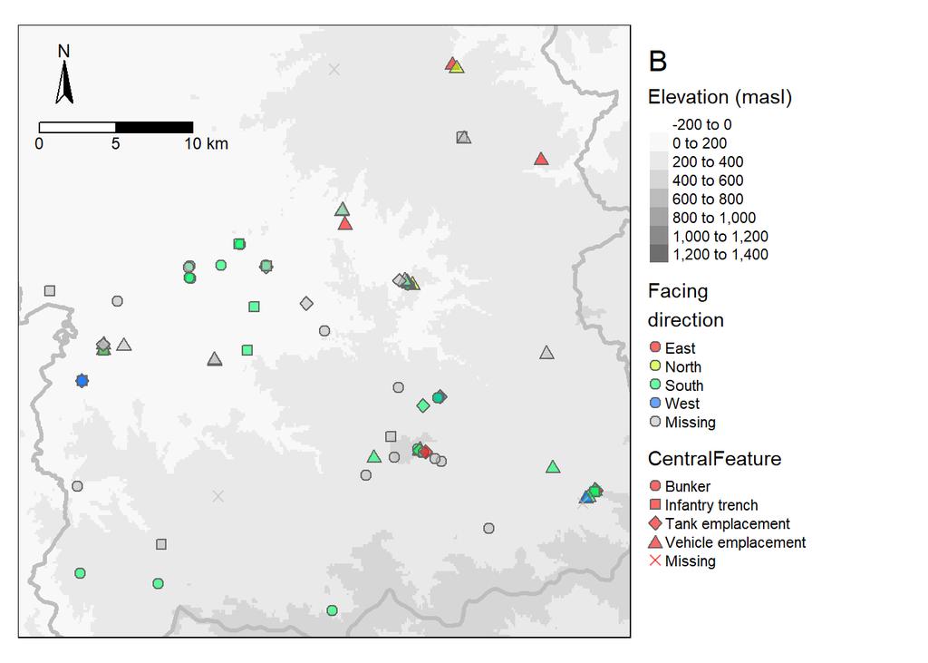

```r
color_type <- rainbow(length(unique(Yam_bunkers$FD)))
library(tmap)

FeatureType_col <- tm_shape(Y_elev, bbox = st_bbox(st_buffer(st_geometry(Yam_bunkers[1,
    ]), 20000))) + tm_raster(alpha = 0.6, title = "Elevation (masl)") + tm_shape(Yam_bunkers,
    bbox = st_bbox(st_buffer(st_geometry(Yam_bunkers[1, ]), 20000))) + tm_dots(col = "FD",
    shape = "CentralFeature", palette = color_type, title = "Facing \ndirection",
    alpha = 0.6, size = 0.3) + tm_shape(Y_region) + tm_borders(col = "grey", lwd = 3) +
    tm_compass(type = "arrow", position = c("left", "top")) + tm_scale_bar(position = c("left",
    "top"), breaks = c(0, 5, 10), text.size = 0.75) + tm_layout(title = "B", legend.outside = TRUE)


FeatureType_bw <- tm_shape(Y_elev, bbox = st_bbox(st_buffer(st_geometry(Yam_bunkers[1,
    ]), 20000))) + tm_raster(alpha = 0.6, palette = "Greys", title = "Elevation (masl)") +
    tm_shape(Yam_bunkers, bbox = st_bbox(st_buffer(st_geometry(Yam_bunkers[1, ]),
        20000))) + tm_dots(col = "FD", shape = "CentralFeature", palette = color_type,
    title = "Facing \ndirection", alpha = 0.6, size = 0.3) + tm_shape(Y_region) +
    tm_borders(col = "grey", lwd = 3) + tm_compass(type = "arrow", position = c("left",
    "top")) + tm_scale_bar(position = c("left", "top"), breaks = c(0, 5, 10), text.size = 0.75) +
    tm_layout(title = "B", legend.outside = TRUE)

FeatureType_bw
```

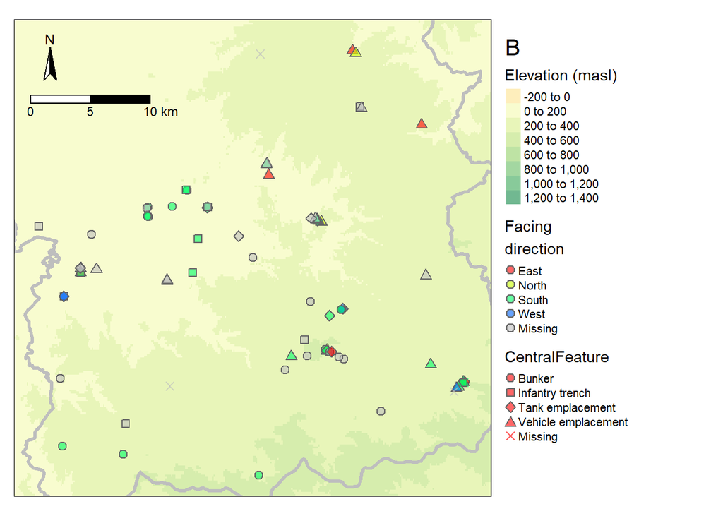

```r
FeatureType_col
```

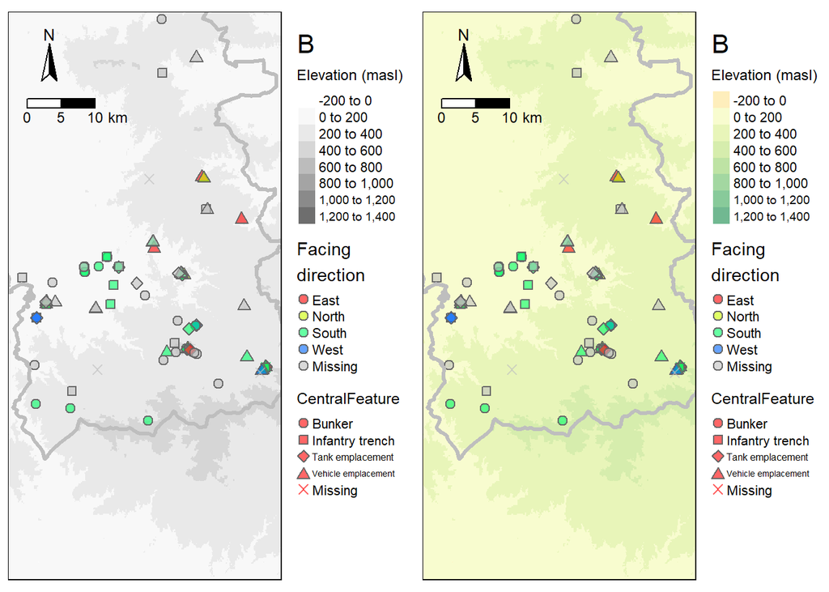

```r
# Eventually we chose one, but let's compare side-by-side
current.mode <- tmap_mode("plot")
tmap_arrange(FeatureType_bw, FeatureType_col)
```

```r
tmap_mode(current.mode)
```

### Combine feature type and facing direction at 10 km scale

```r
table(Yam_bunkers$FacingDirection)
```

```
     East     North Northeast     South Southeast Southwest      West
        7         2         2        22         3         3         5
```

```r
table(Yam_bunkers$FD)
```

```
 East North South  West
    7     4    28     5
```

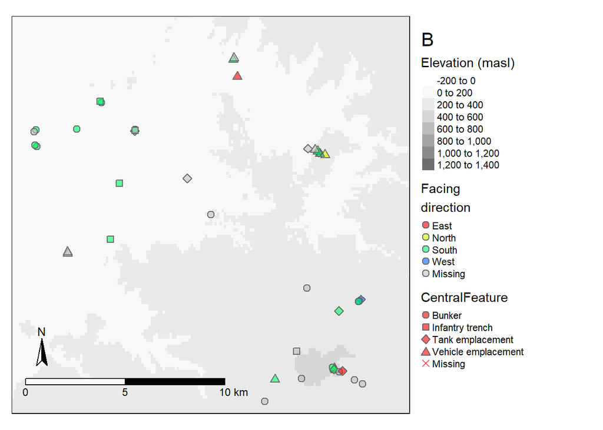

```r
color_type <- rainbow(length(unique(Yam_bunkers$FD)))
library(tmap)
tm_shape(Y_elev, bbox = st_bbox(st_buffer(st_geometry(Yam_bunkers[1, ]), 10000))) +
    tm_raster(alpha = 0.6, palette = "Greys", title = "Elevation (masl)") + tm_shape(Yam_bunkers,
    bbox = st_bbox(st_buffer(st_geometry(Yam_bunkers[1, ]), 10000))) + tm_dots(col = "FD",
    shape = "CentralFeature", palette = color_type, title = "Facing \ndirection",
    alpha = 0.6, size = 0.3) + tm_shape(Y_region) + tm_borders(col = "grey", lwd = 2) +
    tm_compass(type = "arrow", position = c("left", "bottom")) + tm_scale_bar(position = c("left",
    "bottom"), breaks = c(0, 5, 10), text.size = 0.75) + tm_layout(title = "B", legend.outside = TRUE)
```

### Combine feature type and facing direction at 1 km scale around Sitovo[3] or [44]

[3] and [44] are point within the two major clusters in the border area

```r
table(Yam_bunkers$FacingDirection)
```

```
     East     North Northeast     South Southeast Southwest      West
        7         2         2        22         3         3         5
```

```r
table(Yam_bunkers$FD)
```

```
 East North South  West
    7     4    28     5
```

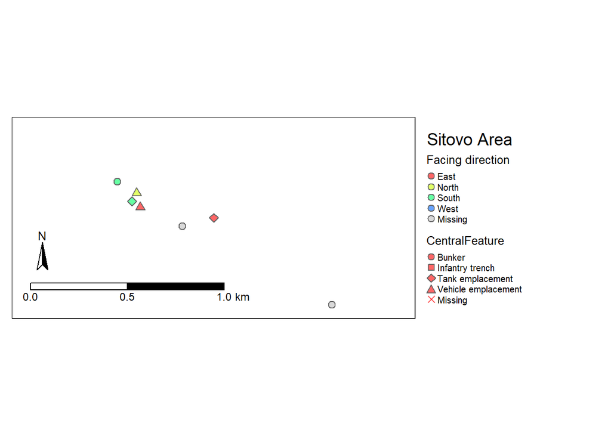

```r
color_type <- rainbow(length(unique(Yam_bunkers$FD)))
library(tmap)

box <- st_bbox(st_buffer(st_geometry(Yam_bunkers[44, ]), 1000))
diff <- (box[4] - box[2])/2
box[2] <- box[2] + diff/2
box[4] <- box[4] - diff/2
tm_shape(Yam_bunkers, bbox = box) + tm_dots(col = "FD", shape = "CentralFeature",
    palette = color_type, title = "Facing direction", alpha = 0.6, size = 0.3) +
    tm_shape(Y_region) + tm_borders(col = "grey", lwd = 2) + tm_compass(type = "arrow",
    position = c("left", "bottom")) + tm_scale_bar(position = c("left", "bottom"),
    breaks = c(0, 0.5, 1), text.size = 0.75) + tm_layout(title = "Sitovo Area", legend.outside = TRUE)
```

### Try facets on bearing - not great

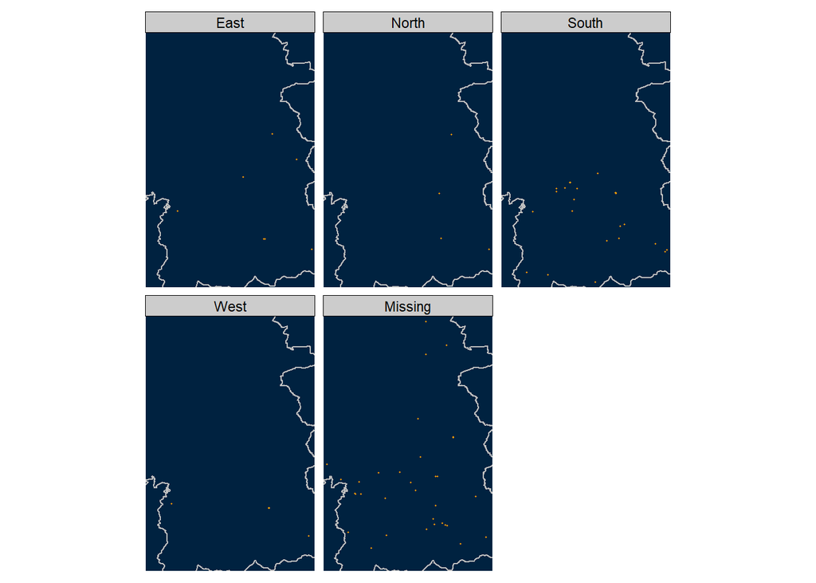

```r
tm_shape(Yam_bunkers) + tm_dots() + tm_facets(by = "FD", free.coords = FALSE) + tm_shape(Y_region) +
    tm_borders(col = "grey", lwd = 2) + tm_style("cobalt")
```

### Try facets on types - not great either

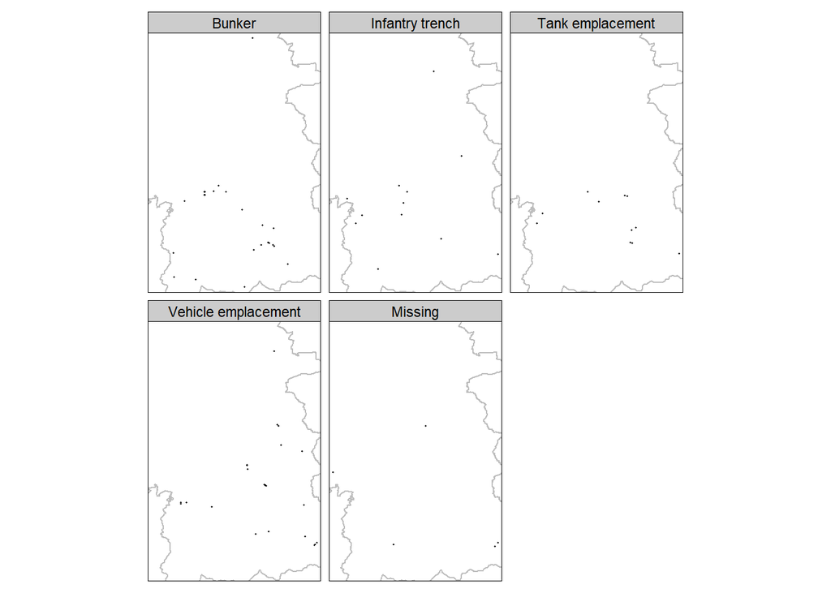

```r
tm_shape(Yam_bunkers) + tm_dots() + tm_facets(by = "CentralFeature", free.coords = FALSE) +
    tm_shape(Y_region) + tm_borders(col = "grey", lwd = 2) + tm_style("white")
```

### Bulgaria inset preparation

```r
# Get admin boundaries for Bulgaria and neighbors and simplify by units of CRS
# (meters)
BG <- getData("GADM", country = "BG", level = 0)
BG <- st_transform(st_as_sf(BG), 32635) %>%
    st_simplify(dTolerance = 1000)

TR <- getData("GADM", country = "TR", level = 0)
TR <- st_transform(st_as_sf(TR), 32635) %>%
    st_simplify(dTolerance = 1000)

GR <- read_sf("../data/GR_bsm_admn_adm0_py_EuroGeoGraphics_2015_pp.shp")
GR <- st_transform(GR, 32635) %>%
    st_simplify(dTolerance = 1000)
RO <- getData("GADM", country = "RO", level = 0)
RO <- st_transform(st_as_sf(RO), 32635) %>%
    st_simplify(dTolerance = 1000)
SE <- getData("GADM", country = "RS", level = 0)
SE <- st_transform(st_as_sf(SE), 32635) %>%
    st_simplify(dTolerance = 1000)
MK <- getData("GADM", country = "MK", level = 0)
MK <- st_transform(st_as_sf(MK), 32635) %>%
    st_simplify(dTolerance = 1000)
```

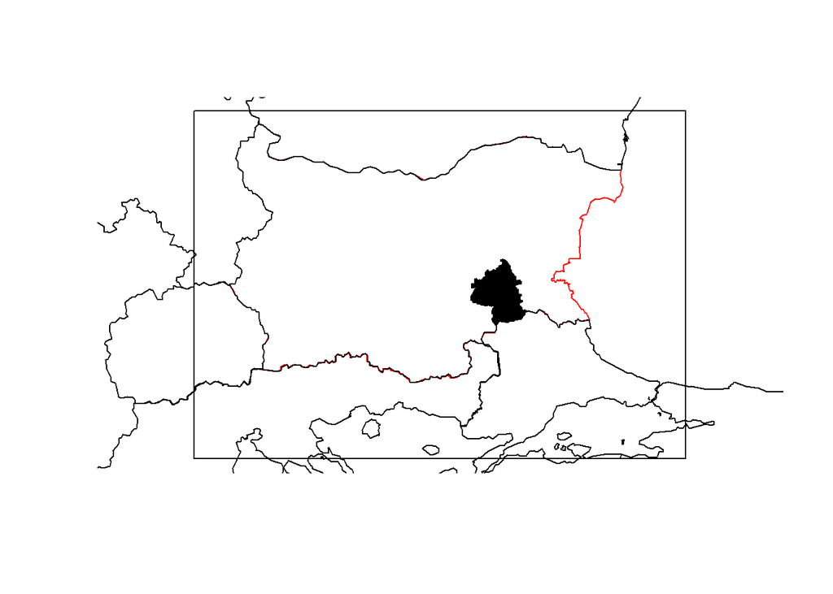

```r
# Plot - but first create a bounding box
box <- st_as_sfc(st_bbox(st_buffer(BG$geometry, 100000)))
# or extent

#e <- drawExtent()
#
# xmin       : 71111.22
# xmax       : 711789.6
# ymin       : 4467237
# ymax       : 4920994

#e <- readRDS("../data/BGextent.rds")


# Convert spatial extent to spatial polygon

# library(Orcs)
# e <- ext2spy(e, crs = "EPSG:32635", as_sf= TRUE)

# Save extent polygon for later retrieval
# saveRDS(e, "../data/BGextent.rds")

# Get BG wider extent
e <- readRDS("../data/BGextent.rds")

# Plot all layers together (centered on BG)

plot(e);#plot(BG$geometry, col = "white", border = "black", lwd = 2, add = T);
plot(BG$geometry, col = "white", border = "red", add = T);
plot(Y_region$geometry,col = "black", border= "black", add = T);plot(GR$geometry, add = T);
plot(TR$geometry, add = T);plot(RO$geometry, add = T);plot(SE$geometry, add = T);plot(MK$geometry, add = T)
```

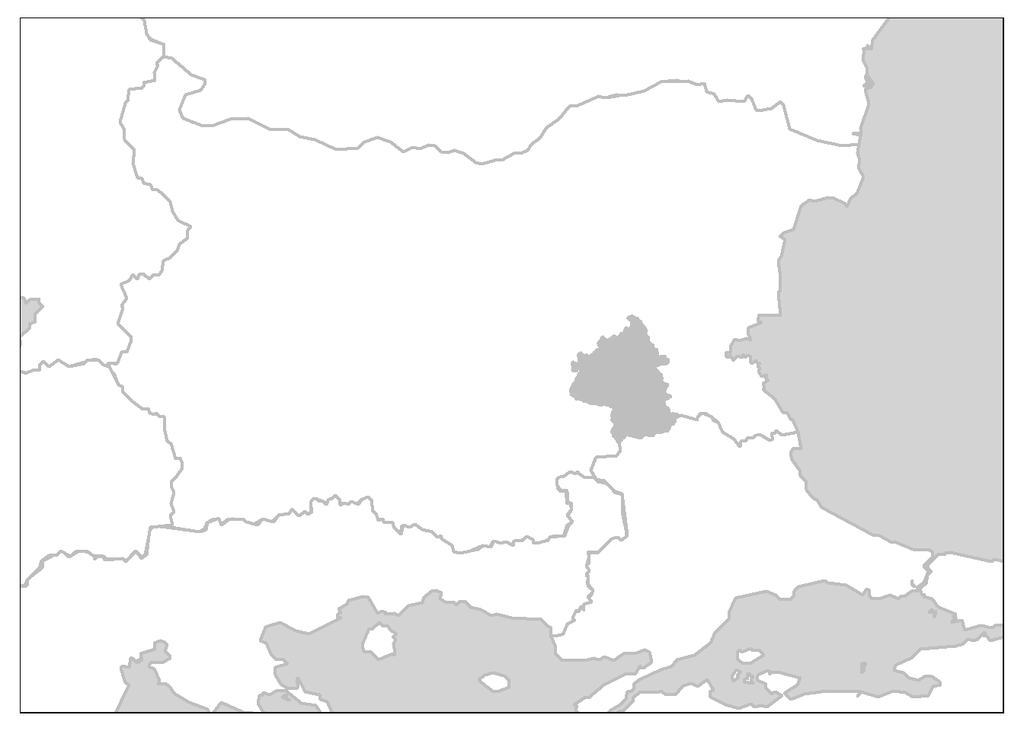

```r
# Make a map object with a neat style
bg_inset <- tm_shape(BG$geometry, bbox = e) + tm_polygons(col = "white", border.col = "grey",
    lty = "solid", lwd = 2) + tm_shape(GR$geometry) + tm_polygons(col = "white",
    border.col = "grey", lty = "solid", lwd = 2) + tm_shape(TR$geometry) + tm_polygons(col = "white",
    border.col = "grey", lty = "solid", lwd = 2) + tm_shape(RO$geometry) + tm_polygons(col = "white",
    border.col = "grey", lty = "solid", lwd = 2) + tm_shape(SE$geometry) + tm_polygons(col = "white",
    border.col = "grey", lty = "solid", lwd = 2) + tm_shape(MK$geometry) + tm_polygons(col = "white",
    border.col = "grey", lty = "solid", lwd = 2) + tm_shape(Y_region$geometry) +
    tm_polygons(col = "grey", border.col = "grey", lty = "solid", lwd = 2) + tm_layout(bg.color = "lightgrey")

bg_inset
```

Prepare to print with the inset. It prints to external file

```r
library(tmaptools)
library(grid)

# change back to the plotting mode tmap_mode('plot')

pdf("Figure01.pdf", width = 5)
# PPAP
overview_yammnds

# print insets
print(bg_inset, vp = viewport(x = 0.17, y = 0.82, width = 0.3, height = 0.3))

dev.off()
```